# Readme

## **Nx_Network_Basics_wifi application description**

This application provides an example of Azure RTOS NetX/NetXDuo stack usage.

It demonstrates WiFi connectivity on Cypress module for the STM32H747I board, with scan, ping, echo and HTTP download network functionalities.

- At first the application performs a scan function and displays the list of access points, then it displays the help command list on the console other the USART1.
- End-user can enter any of the proposed commands:
  - ping : ping a remote host and display time to perform ping request
  - echo : send 10 x 100 bytes to an echo server (armMBED@ one) and check that return data are identical to the one sent
  - scan : list available WiFi access points
  - http : download a file from an HTTP server, http (default url is `http://public.st.free.fr/500MO.bin`)

#### **Expected success behavior**

- Output of the command is displayed over the USART1 console.
- Depending on the command, bit rates or time durations can be displayed.

#### **Error behaviors**

- An error message is displayed over the USART1 console.

#### **Assumptions if any**

- The application is using the DHCP to acquire IP address, thus a DHCP server should be reachable by the board in the LAN used to test the application.

#### **ThreadX usage hints**

- ThreadX uses the Systick as time base, thus it is mandatory that the HAL uses a separate time base through the TIM IPs.
- ThreadX is configured with 1000 ticks/sec, this should be taken into account when using delays or timeouts at application. It is always possible to reconfigure it in the `tx_user.h`, the `TX_TIMER_TICKS_PER_SECOND` define, but this should be reflected in `tx_initialize_low_level.S` file too.
- ThreadX is disabling all interrupts during kernel start-up to avoid any unexpected behavior, therefore all system related calls (HAL, BSP) should be done either at the beginning of the application or inside the thread entry functions.
- ThreadX offers the `tx_application_define()` function, that is automatically called by the tx_kernel_enter() API. It is highly recommended to use it to create all applications ThreadX related resources (threads, semaphores, memory pools…) but it should not in any way contain a system API call (HAL or BSP).
- Using dynamic memory allocation requires to apply some changes to the linker file. ThreadX needs to pass a pointer to the first free memory location in RAM to the `tx_application_define()` function, using the `first_unused_memory` argument. This requires changes in the linker files to expose this memory location.
  - For EWARM add the following section into the .icf file:

  ```
     place in RAM_region    { last section FREE_MEM };
  ```

  - For MDK-ARM: either define the RW_IRAM1 region in the “.sct” file or modify the line below in `tx_initialize_low_level.S` to match the memory region being used

  ```
      LDR r1, =|Image$$RW_IRAM1$$ZI$$Limit|
  ```

  - For STM32CubeIDE add the following section into the .ld file:

  ```
      ._threadx_heap :
      {
       . = ALIGN(8);
       __RAM_segment_used_end__ = .;
       . = . + 64K;
       . = ALIGN(8);
      } >RAM_D1 AT> RAM_D1
  ```

  The simplest way to provide memory for ThreadX is to define a new section, see ._threadx_heap above. In the example above the ThreadX heap size is set to 64KBytes. The `._threadx_heap` must be located between the `.bss` and the `._user_heap_stack sections` in the linker script. Caution: Make sure that ThreadX does not need more than the provided heap memory (64KBytes in this example). Read more in STM32CubeIDE User Guide, chapter: “Linker script”.
  - The `tx_initialize_low_level.S` should be also modified to enable the `USE_DYNAMIC_MEMORY_ALLOCATION` compilation flag.

#### **NetX Duo usage hints**

For more details about the MPU configuration please refer to the [AN4838](https://www.st.com/resource/en/application_note/dm00272912-managing-memory-protection-unit-in-stm32-mcus-stmicroelectronics.pdf)

### **Keywords**

RTOS, Network, ThreadX, NetXDuo, WiFi, Station mode, Ping, Scan, Echo, HTTP, microSD

### **Hardware and Software environment**

- This application runs on STM32H747xx devices.
- This application has been tested with STMicroelectronics STM32H747I-DISCO boards Revision: MB1248-H747I-D02 and can be easily tailored to any other supported device and development board.
- A daughter board with the WiFi module is to be plugged into the microSD card connector CN12 of the STM32H747I-DISCO board.
- The daughterboard that was used is made up of:
  - A Murata uSD-M.2 Adapter Kit rev A (*J1 position 2-3, VBAT from microSD connector*)
  - The 1DX M.2 Module for the Cypress WiFi (CYW4343W)

> Connect *Pin 20 of STMod+ connector P2 of STM32H747I-DISCO* to the uSD M.2 Adapter (*J9 pin3 WL_REG_ON_HOST*) that supports the Cypress device as described with the below pictures:

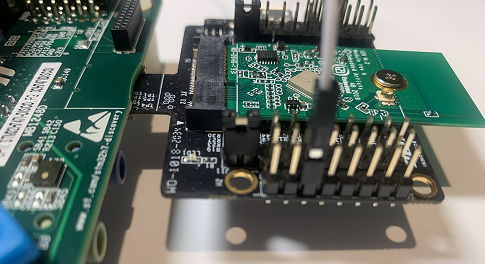

[figure not shown]

- This application uses USART1 to provide a console for commands, the hyperterminal configuration is as follows:
  - BaudRate = 115200 baud
  - Word Length = 8 Bits
  - Stop Bit = 1
  - Parity = None
  - Flow control = None
  - Line endings set to LF (transmit) and LF (receive).
- This application requires a WiFi access point to connect to:
  - With a transparent Internet connectivity: no proxy, no firewall blocking the outgoing traffic.
  - Running a DHCP server delivering the IP and DNS configuration to the board.

### **How to use it ?**

In order to make the program work, you must do the following:

- Open your preferred toolchain
- Edit the file `CM7/Core/Inc/cy_wifi_conf.h` to enter the name of your WiFi access point (`WIFI_SSID`) to connect to and its password (`WIFI_PASSWORD`).
- For each target configuration (Nx_Network_Basics_wifi_CM4 first then Nx_Network_Basics_wifi_CM7) :
  - Rebuild all files
  - Load images into target memory
- After loading the two images, you have to reset the board in order to boot (Cortex-M7) and CPU2 (Cortex-M4) at once.
- Run the application